# STAA57 - WorkSheet 10

Name: , ID#:

**Goal**: Practice estimation and the bootstrap.

Use the Labour Fource Survey (LFS) data for Toronto.

```r
lfs = read_csv('./data/LFS_Toronto.csv')
```

1. Give point estimates of the unemployment rate broken down by education level (variable `educ`; see [codebook](http://sda.chass.utoronto.ca/sdaweb/dli2/lfsv6/2018/doc/lfsv.htm) ). The answer should give an unemployment rate for each education level.
2. Use the `infer` package to generate 500 bootstrap samples for the BSc education level (`educ == 5`), and calculate their unemployment rate.
3. Use your boostrap samples to create a *histogram* of the sampling distribution of the BSc-level unemployment rate. Overlay the value of the point estimate as a vertical line (`geom_vline()`).

4.Use your boostrap samples to create a *quantile-based* 90% confidence interval for the BSc unemployment rate.

5. Going back to the original LFS data, focus on currently working individuals (`lfsstat == 1`) with a BSc degree (`educ == 5`), and estimate the BSc-level average hourly earnings (`hrlyearn`) for each `sex` (1=MALE, 2=FEMALE). Note that there are missing values (`NA`) in earnings, which you can remove from your analysis. What is a potential sampling problem with the missing values?
6. Assume you wanted to create a bootstrap CI around each mean hourly earnings. Would you resample from each sex separately, or from both sexes combined? Justify your answer.
7. Use bootstrap sampling with 500 iterations *for each sex separately*, to create *standard error-based* 95% CI’s for the mean hourly earnings.
8. [EXTRA] The final weight variable (`fweight`) provides a number corresponding to the size of the population represented by that particular observation. E.g. if you were randomly sampling 20 observations from a population of size 1,000, each observation would receive an equal weight of 50 (=1,000/20). Differences in `fweight` reflect varying coverage of different geographic areas in the survey.  
   Estimate the *total number* of working individuals (`lfsstat==1`) in the month of Nov. 2018 (`survmnth==11`) for different education levels, by summing up their `fweight` values. Plot your estimates in a barplot like the one below:

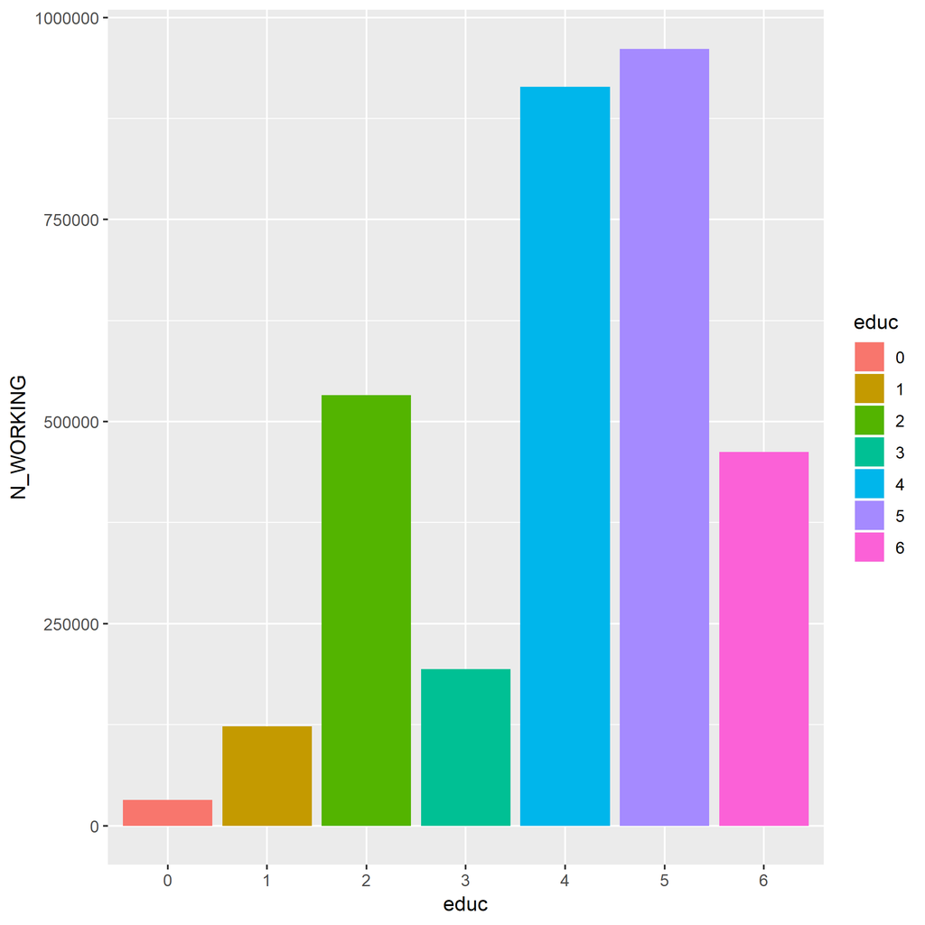